# Tarea 1

### Desarrollo Experimental 2

### Julio Cesar Cons Calderón

#### Objetivos

Realizar rutinas (seguir protocolos) para comprobar el buen estado inicial del equipo de cómputo, recordar comandos básicos, revisión de edición, graficación y compilación en actividades específicas.

##### Actividad 0

- Conectarse al servidor del centro de computo

[figure not shown]

- Conectarse al servidor del centro de computo
- Crear el directorio DE2
- Cambiarse al directorio DE2 y generar otro directorio Tarea1
- Regresar al directorio raiz
- Salirse de la coneccion al servidor

[figure not shown]

- Consultar su correo institucional y guardar en un directorio local los archivos enviadospor el profesor<
- Transferir el archivo del inciso anterior al directorio Tarea 1 generado en el servidor
- Salirse del protocolo de transferencia

[figure not shown]

- Volver a conectarse al servidor e ir al directorio Tarea 1
- Confirmar que el directorio contiene el archivo transferido
- Visualizar el contenido del archivo

[figure not shown]

- Gráficar los archivos

[figure not shown]

##### Actividad 1

Graficaremos la funcion:

$$ f(x)=e^\frac{-x^2}{2} $$

###### Pasos a seguir

1. Importamos las librerias necesarias para la actividad. Seran tres librerias.
- NumPy es una biblioteca para el lenguaje de programación Python que da soporte para crear vectores y matrices grandes multidimensionales, junto con una gran colección de funciones matemáticas de alto nivel para operar con ellas.
- Pandas es una biblioteca de software escrita como extensión de NumPy para manipulación y análisis de datos para el lenguaje de programación Python. En particular, ofrece estructuras de datos y operaciones para manipular tablas numéricas y series temporales.
- Matplotlib es una biblioteca para la generación de gráficos a partir de datos contenidos en listas o arrays en el lenguaje de programación Python y su extensión matemática NumPy.

```python
import numpy as np
import pandas as pd
from matplotlib import pyplot as plt
import math
```

1. Definimos una función en Python. Se usara el comando def que nos define la función y como unico argumento sera x.

```python
def funcion(x):
    f=np.exp(-x**2/2)
    return f
```

1. Asignamos valor de inicio y final al intervalo en el cual se va a graficar la función.

```python
x0=-3
xf=3
```

1. Creamos un array $x$ que vaya desde el intervalo $[x_0,x_f]$ y tenga un step de 0.1.
2. Despues creamos otro array que contenga los valores de la función valuado en cada valor del elemento $x$.
3. Metemos los arrays en un marco de datos que podamos exportar a un archivo txt.

```python
x=np.arange(x0,xf,step=0.1)
y=[funcion(z) for z in x]
df=pd.DataFrame({"x":x,"f(x)":y})
df.to_csv("grafica.txt",index=None)
```

1. Leemos el archivo txt que habiamos exportado en el paso anterior y lo guardamos en un marco de datos llamado read.

```python
read= pd.read_csv("grafica.txt")
```

1. Graficamos los datos guardados en el marco de datos read. Los graficamos en forma de puntos y continua.

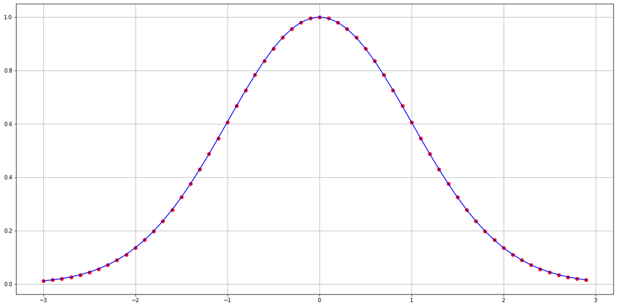

```python
plt.figure(figsize=([20,10]))
plt.plot(read["x"],read["f(x)"], 'ro')
plt.plot(read["x"],read["f(x)"], 'b')

plt.grid()
plt.show()
```

##### Actividad 2

Elaborar un programa para colocar N partículas (puntos) en una recta de longitud L, de forma tal que la distancia de separación entre ellas sea uniforme.

- Ejecutar su programa para N y L dadas por Usted.
- Mostrar gráficamente la distribución de partículas (puntos) obtenida.

###### Pasos a seguir

```python
L=10
N=10
i=0
x=[]
while i<N:
    x.append(i*L/(N-1))
    i = i+1

y = [_*0 for _ in x]
```

1. Graficaremos los valores de x. Lo haremos primero de forma discreta y despues de forma continua para simular la linea recta.

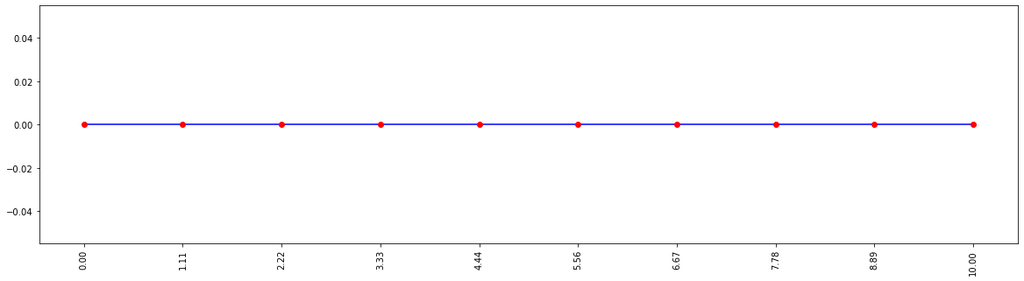

```python
plt.figure(figsize=([20,5]))
plt.plot(x, y, 'b')
plt.plot(x, y, 'ro')
plt.xticks(x, rotation=90)
plt.show()
```

##### Actividad 3

Elaborar un programa para colocar partículas (puntos) en una superficie cuadrada de lado L, de forma tal que formen un arreglo cuadrangular.

- Ejecutar su programa para $N$ y $L$ dadas por Usted.
- Mostrar gráficamente la distribución de partículas obtenida

##### Pasos a seguir

1. Basicamente, el problema se basa en usar el mismo array pero aplicar el producto cartesiano a si mismo. Esto generará una pareja de pares que a cada valor del array $x$ le asignara cada valor del mismo array.
2. Para generar un producto cartesiano usamos el comando set para generar un conjunto de pares. Despues creamos dos ciclos donde a la primer valor del par le asignamos cada elemento del array $x$. El segundo ciclo le asigna al segundo valor del par un elemento del array $x$.

```python
p=set([(z, y) for z in x for y in x])
```

1. Separamos el valor de los pares en dos arrays diferentes. Así, tendremos la facilidad de graficarlos.

```python
x_val = [x[0] for x in p]
y_val = [x[1] for x in p]
```

1. Graficamos la cuadricula.

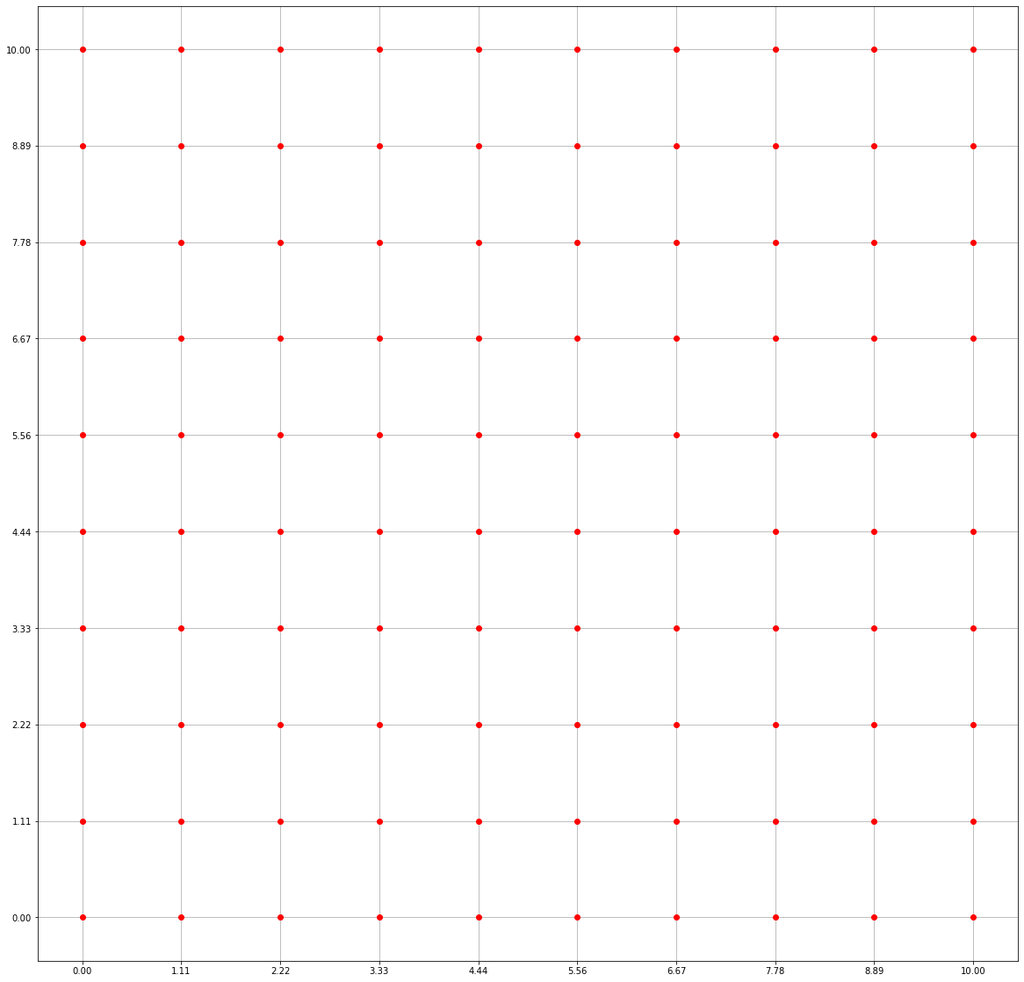

```python
plt.figure(figsize=([20,20]))
plt.plot(x_val,y_val, 'ro')
plt.grid()
plt.xticks(x)
plt.yticks(x)
plt.show()
```

##### Observaciones finales:

Esta actividad fue muy ilustrativa. Mis conocimientos usando la consola de Unix es limitado pero las pocas lineas de comando que usé me ayudo a recordar algunos elementos de Fortran. Para mi, el Lenguaje Python junto con el IDE Jupyter Notebook, forman una excelente dupla a la hora de resolver problemas que no necesiten lineas de codigo extensas.